# Body mass index in US adults

Dataset 10: NHANES adults (2009-10 and 2011-12 extract)

RSR feasibility analysis

2026-08-03

# Introduction

The National Health and Nutrition Examination Survey (NHANES) is a continuous cross-sectional survey of the civilian non-institutionalised US population that pairs a household interview with a standardised examination, including measured height and weight. This teaching extract holds 488 adults aged 21 to 80 from the 2009-10 and 2011-12 cycles. Body mass index is the standard population measure of adiposity and the proximal risk factor for type 2 diabetes, hypertension and several cancers, so identifying which social and behavioural characteristics track with it is a standard descriptive epidemiology question.

**Aim.** Among these US adults, we examined which of age, sex, race/ethnicity, education, income-to-poverty ratio, recreational physical activity, sleep duration, smoking history and self-rated general health are independently associated with BMI, mutually adjusting for the others.

This is a *Purpose 3* analysis: several predictors are of interest and the question is which remain associated with the outcome after mutual adjustment.

# Methods

**Data source.** NHANES 2009-10 and 2011-12, a complex multistage probability sample of the US civilian non-institutionalised population. This extract contains 488 adults with 31 variables. Height and weight were measured in the mobile examination centre, not self-reported.

**Variables.** The outcome is `bmi`, body mass index in kg/m2, treated as continuous. Predictors are age (years), sex (reference female), race/ethnicity (reference White, the largest group), education (reference College Grad, the largest group), income-to-poverty ratio (household income as a multiple of the federal poverty line), recreational moderate or vigorous physical activity (reference no), usual sleep hours per night, ever having smoked 100 cigarettes (reference no) and self-rated general health collapsed to three levels (reference Excellent/Very good).

Three variables are deliberately excluded. `weight_kg` and `height_cm` are excluded because `bmi` is exactly `weight_kg / (height_cm/100)^2` in this file - the largest absolute discrepancy across all rows is 0.05 kg/m2, which is pure rounding - so including any two of the three produces a deterministic relationship and a meaningless model. `obese` is excluded because it is exactly `bmi >= 30` on every row where BMI is observed; regressing BMI on a dichotomised copy of itself is circular.

**Statistical analysis.** `lm()`, justified because the outcome is continuous. We fitted a univariable model for each predictor first, then a single multivariable model containing all of them. Predictors were chosen in advance on subject-matter grounds, not by significance. Significance threshold 0.05; estimates are reported with 95% confidence intervals. Assumptions were checked with `performance::check_model()`, and because non-constant variance was flagged we additionally report HC3 heteroscedasticity-consistent standard errors. Models are **unweighted**: the NHANES survey weights, strata and primary sampling units are not carried in this extract, so no result here is a nationally representative estimate. Analysis used R version 4.6.0 (2026-04-24) with tidyverse, gtsummary and performance.

**Missing data.** Complete-case analysis: 410 of 488 rows were analysed (78 dropped). The main cost is `general_health` (48 missing) and `poverty_ratio` (38 missing). Only 172 of 488 rows are complete on *every* variable in the file, so listwise deletion is a live threat and the complete-case N is reported for every model.

# Results

## Sample characteristics

**Table 1. Sample characteristics.**

| **Characteristic** | **N** | **N = 410**<sup>1</sup> |
| --- | --- | --- |
| BMI (kg/m2) | 410 | 28 (25, 33) |
| Age (years) | 410 | 50 (37, 64) |
| Sex | 410 |  |
| Female |  | 216 (53%) |
| Male |  | 194 (47%) |
| Race/ethnicity | 410 |  |
| White |  | 301 (73%) |
| Black |  | 46 (11%) |
| Hispanic |  | 17 (4.1%) |
| Mexican |  | 30 (7.3%) |
| Other |  | 16 (3.9%) |
| Education | 410 |  |
| College Grad |  | 131 (32%) |
| Some College |  | 121 (30%) |
| High School |  | 83 (20%) |
| 9 - 11th Grade |  | 51 (12%) |
| 8th Grade |  | 24 (5.9%) |
| Income-to-poverty ratio | 410 | 3.23 (1.57, 4.98) |
| Recreationally physically active | 410 | 203 (50%) |
| Sleep (hours/night) | 410 | 7.00 (6.00, 8.00) |
| Ever smoked 100+ cigarettes | 410 | 184 (45%) |
| Self-rated general health | 410 |  |
| Excellent/Very good |  | 192 (47%) |
| Good |  | 162 (40%) |
| Fair/Poor |  | 56 (14%) |

<sup>1</sup> Median (Q1, Q3); n (%)

## Exploratory figure

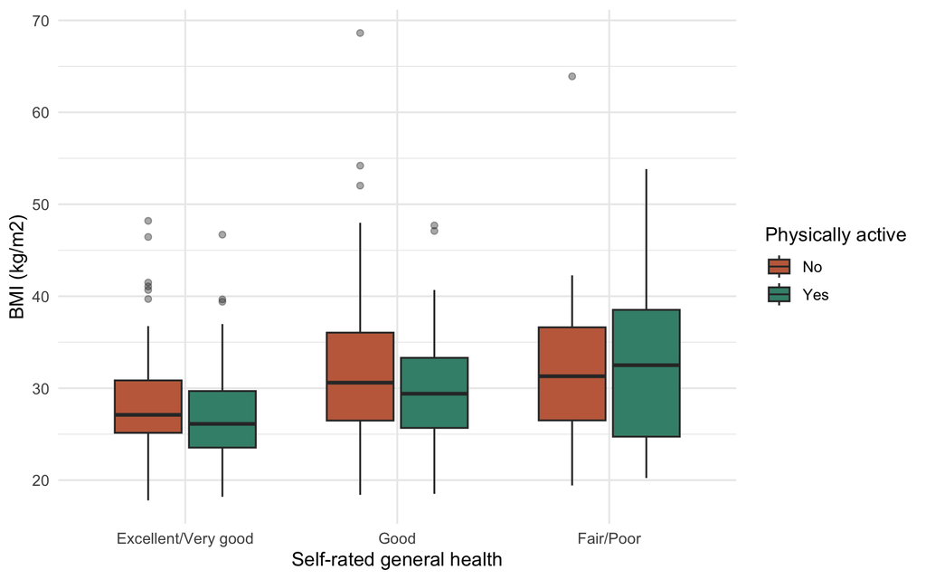

Figure 1. BMI by self-rated general health and physical activity.

## Univariable models

| **Characteristic** | **N** | **Beta** | **95% CI** | **p-value** |
| --- | --- | --- | --- | --- |
| Age (years) | 410 | 0.00 | -0.04, 0.04 | 0.8 |
| Sex | 410 |  |  |  |
| Female |  | — | — |  |
| Male |  | -1.4 | -2.8, -0.08 | 0.038 |
| Race/ethnicity | 410 |  |  |  |
| White |  | — | — |  |
| Black |  | 0.63 | -1.5, 2.8 | 0.6 |
| Hispanic |  | 3.7 | 0.31, 7.1 | 0.032 |
| Mexican |  | -0.01 | -2.6, 2.6 | >0.9 |
| Other |  | -5.6 | -9.0, -2.1 | 0.002 |
| Education | 410 |  |  |  |
| College Grad |  | — | — |  |
| Some College |  | 1.5 | -0.27, 3.2 | 0.10 |
| High School |  | 1.6 | -0.29, 3.6 | 0.10 |
| 9 - 11th Grade |  | 1.3 | -0.95, 3.6 | 0.3 |
| 8th Grade |  | -0.42 | -3.5, 2.6 | 0.8 |
| Income-to-poverty ratio | 410 | -0.57 | -0.99, -0.15 | 0.008 |
| Recreationally physically active | 410 |  |  |  |
| No |  | — | — |  |
| Yes |  | -2.1 | -3.5, -0.80 | 0.002 |
| Sleep (hours/night) | 410 | -0.28 | -0.78, 0.22 | 0.3 |
| Ever smoked 100+ cigarettes | 410 |  |  |  |
| No |  | — | — |  |
| Yes |  | 0.08 | -1.3, 1.4 | >0.9 |
| Self-rated general health | 410 |  |  |  |
| Excellent/Very good |  | — | — |  |
| Good |  | 3.4 | 2.0, 4.8 | <0.001 |
| Fair/Poor |  | 4.9 | 2.9, 6.9 | <0.001 |

Abbreviation: CI = Confidence Interval

Self-rated health is the strongest crude predictor: compared with participants rating their health Excellent or Very good, those rating it Good average 3.41 kg/m2 (95% CI 2.00 to 4.81) higher BMI (p <0.001) and those rating it Fair or Poor average 4.91 kg/m2 (95% CI 2.91 to 6.91) higher (p <0.001). Recreational physical activity is associated with -2.14 kg/m2 (95% CI -3.48 to -0.80) (p = 0.002) lower BMI, each unit of income-to-poverty ratio with -0.57 kg/m2 (95% CI -0.99 to -0.15) (p = 0.008), and men average -1.43 kg/m2 (95% CI -2.78 to -0.08) (p = 0.038) relative to women. Participants in the “Other” race category average -5.57 kg/m2 (95% CI -9.04 to -2.10) (p = 0.002) lower BMI than White participants. Age, education, sleep hours and smoking show no crude association.

## Why adjustment is needed

**Income-to-poverty ratio** is a clear confounder of the education and race/ethnicity associations: education and income are strongly correlated in this sample, and higher income is associated with lower BMI, so part of any crude education gradient is really an income gradient. **Self-rated general health** is the other variable that must be handled explicitly - it is associated with income, education and physical activity (people who are poorer, less educated and inactive rate their health worse) and it is strongly associated with BMI, so it will absorb part of every socioeconomic and behavioural coefficient. Note that the causal direction here is ambiguous: high BMI plausibly *causes* worse self-rated health, in which case adjusting for it is adjusting for a mediator rather than a confounder, and the adjusted activity and income coefficients are correspondingly hard to interpret. **Age** confounds the sleep and activity associations, since older participants sleep and exercise differently and BMI varies with age. Mutual adjustment lets each coefficient be read as a comparison between participants alike on the other measured characteristics, with the mediation caveat kept in view.

## Multivariable model

| **Characteristic** | **Beta** | **95% CI** | **p-value** |
| --- | --- | --- | --- |
| Age (years) | -0.01 | -0.05, 0.04 | 0.8 |
| Sex |  |  |  |
| Female | — | — |  |
| Male | -0.41 | -1.7, 0.92 | 0.5 |
| Race/ethnicity |  |  |  |
| White | — | — |  |
| Black | -0.41 | -2.5, 1.7 | 0.7 |
| Hispanic | 3.5 | 0.17, 6.8 | 0.040 |
| Mexican | -0.78 | -3.8, 2.3 | 0.6 |
| Other | -5.6 | -9.0, -2.2 | 0.001 |
| Education |  |  |  |
| College Grad | — | — |  |
| Some College | 0.29 | -1.4, 2.0 | 0.7 |
| High School | -0.42 | -2.4, 1.6 | 0.7 |
| 9 - 11th Grade | -0.61 | -2.9, 1.7 | 0.6 |
| 8th Grade | -2.8 | -6.4, 0.84 | 0.13 |
| Income-to-poverty ratio | -0.30 | -0.77, 0.18 | 0.2 |
| Recreationally physically active |  |  |  |
| No | — | — |  |
| Yes | -1.6 | -3.0, -0.26 | 0.020 |
| Sleep (hours/night) | 0.02 | -0.47, 0.51 | >0.9 |
| Ever smoked 100+ cigarettes |  |  |  |
| No | — | — |  |
| Yes | -0.39 | -1.8, 0.98 | 0.6 |
| Self-rated general health |  |  |  |
| Excellent/Very good | — | — |  |
| Good | 3.1 | 1.7, 4.6 | <0.001 |
| Fair/Poor | 4.7 | 2.5, 6.9 | <0.001 |

Abbreviation: CI = Confidence Interval

**Model fit: multivariable linear model for BMI**

| Statistic | Value |
| --- | --- |
| Complete-case N | 410 |
| Parameters (excl. intercept) | 16 |
| R-squared | 0.143 |
| Adjusted R-squared | 0.108 |
| Residual SE (kg/m2) | 6.58 |

The model explains 14.3% of the variance in BMI (adjusted R-squared 0.108). The gap between R-squared and adjusted R-squared is noticeable because the model spends 16 parameters on 410 observations, many of them on category contrasts that contribute little. Among participants of the same age, sex, race, education, income, activity, sleep and smoking status, rating one’s health as Good rather than Excellent/Very good is associated with 3.12 kg/m2 (95% CI 1.67 to 4.57) higher BMI (p <0.001), and Fair/Poor with 4.73 kg/m2 (95% CI 2.55 to 6.91) higher (p <0.001). Physical activity remains associated with -1.65 kg/m2 (95% CI -3.03 to -0.26) (p = 0.020). Participants in the “Other” race group average -5.65 kg/m2 (95% CI -9.05 to -2.25) (p = 0.001) and Hispanic participants 3.47 kg/m2 (95% CI 0.17 to 6.78) (p = 0.040) relative to White participants. Age, sex, education, income, sleep and smoking are not independently associated. These are associations among the participants observed, not effects of intervening.

## Unadjusted versus adjusted

**Table 2. Unadjusted and adjusted estimates.**

| **Characteristic** | **Unadjusted** **N** | **Unadjusted** **Beta** | **Unadjusted** **95% CI** | **Unadjusted** **p-value** | **Adjusted** **Beta** | **Adjusted** **95% CI** | **Adjusted** **p-value** |
| --- | --- | --- | --- | --- | --- | --- | --- |
| Age (years) | 410 | 0.00 | -0.04, 0.04 | 0.8 | -0.01 | -0.05, 0.04 | 0.8 |
| Sex | 410 |  |  |  |  |  |  |
| Female |  | — | — |  | — | — |  |
| Male |  | -1.4 | -2.8, -0.08 | 0.038 | -0.41 | -1.7, 0.92 | 0.5 |
| Race/ethnicity | 410 |  |  |  |  |  |  |
| White |  | — | — |  | — | — |  |
| Black |  | 0.63 | -1.5, 2.8 | 0.6 | -0.41 | -2.5, 1.7 | 0.7 |
| Hispanic |  | 3.7 | 0.31, 7.1 | 0.032 | 3.5 | 0.17, 6.8 | 0.040 |
| Mexican |  | -0.01 | -2.6, 2.6 | >0.9 | -0.78 | -3.8, 2.3 | 0.6 |
| Other |  | -5.6 | -9.0, -2.1 | 0.002 | -5.6 | -9.0, -2.2 | 0.001 |
| Education | 410 |  |  |  |  |  |  |
| College Grad |  | — | — |  | — | — |  |
| Some College |  | 1.5 | -0.27, 3.2 | 0.10 | 0.29 | -1.4, 2.0 | 0.7 |
| High School |  | 1.6 | -0.29, 3.6 | 0.10 | -0.42 | -2.4, 1.6 | 0.7 |
| 9 - 11th Grade |  | 1.3 | -0.95, 3.6 | 0.3 | -0.61 | -2.9, 1.7 | 0.6 |
| 8th Grade |  | -0.42 | -3.5, 2.6 | 0.8 | -2.8 | -6.4, 0.84 | 0.13 |
| Income-to-poverty ratio | 410 | -0.57 | -0.99, -0.15 | 0.008 | -0.30 | -0.77, 0.18 | 0.2 |
| Recreationally physically active | 410 |  |  |  |  |  |  |
| No |  | — | — |  | — | — |  |
| Yes |  | -2.1 | -3.5, -0.80 | 0.002 | -1.6 | -3.0, -0.26 | 0.020 |
| Sleep (hours/night) | 410 | -0.28 | -0.78, 0.22 | 0.3 | 0.02 | -0.47, 0.51 | >0.9 |
| Ever smoked 100+ cigarettes | 410 |  |  |  |  |  |  |
| No |  | — | — |  | — | — |  |
| Yes |  | 0.08 | -1.3, 1.4 | >0.9 | -0.39 | -1.8, 0.98 | 0.6 |
| Self-rated general health | 410 |  |  |  |  |  |  |
| Excellent/Very good |  | — | — |  | — | — |  |
| Good |  | 3.4 | 2.0, 4.8 | <0.001 | 3.1 | 1.7, 4.6 | <0.001 |
| Fair/Poor |  | 4.9 | 2.9, 6.9 | <0.001 | 4.7 | 2.5, 6.9 | <0.001 |

Abbreviation: CI = Confidence Interval

## Diagnostics

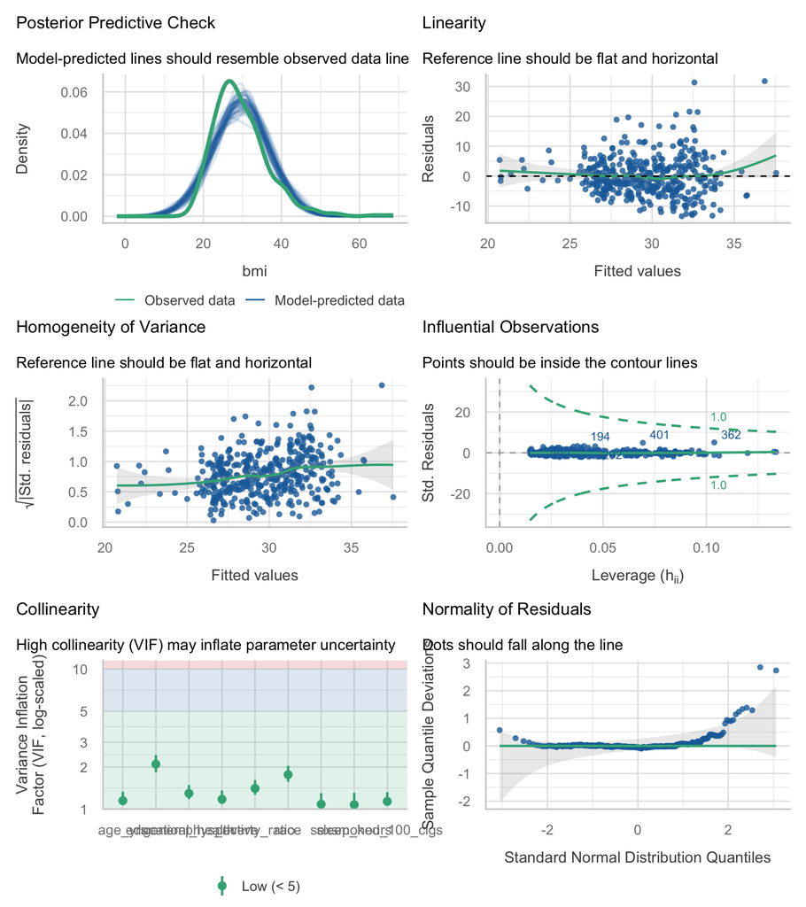

**Table 3. HC3 heteroscedasticity-consistent standard errors.**

| Term | Estimate | SE (OLS) | SE (HC3) | 95% CI (HC3) | p (HC3) |
| --- | --- | --- | --- | --- | --- |
| age_yrs | -0.005 | 0.021 | 0.021 | -0.05 to 0.04 | 0.807 |
| sexMale | -0.410 | 0.679 | 0.659 | -1.71 to 0.89 | 0.534 |
| raceBlack | -0.412 | 1.084 | 1.328 | -3.02 to 2.20 | 0.756 |
| raceHispanic | 3.472 | 1.682 | 2.523 | -1.49 to 8.43 | 0.170 |
| raceMexican | -0.782 | 1.556 | 1.483 | -3.70 to 2.13 | 0.598 |
| raceOther | -5.647 | 1.729 | 1.326 | -8.25 to -3.04 | 0.000 |
| educationSome College | 0.292 | 0.885 | 0.862 | -1.40 to 1.99 | 0.735 |
| educationHigh School | -0.416 | 1.012 | 0.979 | -2.34 to 1.51 | 0.671 |
| education9 - 11th Grade | -0.606 | 1.190 | 1.338 | -3.24 to 2.02 | 0.651 |
| education8th Grade | -2.767 | 1.833 | 1.414 | -5.55 to 0.01 | 0.051 |
| poverty_ratio | -0.299 | 0.241 | 0.243 | -0.78 to 0.18 | 0.219 |
| phys_activeYes | -1.647 | 0.705 | 0.749 | -3.12 to -0.17 | 0.028 |
| sleep_hours | 0.019 | 0.251 | 0.348 | -0.67 to 0.70 | 0.957 |
| smoked_100_cigsYes | -0.387 | 0.696 | 0.699 | -1.76 to 0.99 | 0.580 |
| general_healthGood | 3.120 | 0.737 | 0.718 | 1.71 to 4.53 | 0.000 |
| general_healthFair/Poor | 4.730 | 1.109 | 1.309 | 2.16 to 7.30 | 0.000 |

# Discussion

**Limitations.** The models are unweighted, and the NHANES sampling weights, strata and PSUs are not in this extract, so the sample **must not be described as nationally representative**. The design is cross-sectional, so temporality is unknown; in particular, adjusting for self-rated general health is probably adjusting for a *consequence* of high BMI, which biases the remaining coefficients in an unpredictable direction - this is over-adjustment, not confounder control. Physical activity is a crude yes/no self-report with no intensity or duration, and reverse causation is likely (high BMI reduces exercise). Diet, which is the dominant determinant of BMI, is not measured at all. Complete-case analysis dropped 78 of 488 rows (16%). Residual variance is non-constant and residuals are strongly non-normal; HC3 SEs address inference but not the model’s inability to predict the obese tail. Hispanic (n = 17) and Other (n = 16) groups are small, so those contrasts are unstable. All estimates are associations, not causal effects.

**Future work.** Refit on log(BMI) with the NHANES survey design and dietary recall variables from the full public files, and drop self-rated health from the adjustment set to avoid conditioning on a mediator.

# Feasibility notes

*NOT part of a student report.*